# **Project 2: Determining Credit Worthiness by Classification**

### **Introduction**

Paula McCree-Bailey

Whether we like using credit or not, it has been a way for us to "buy now and pay later". The use of credit began as early as the nineteenth century mainly for purchasing homes. In 1899 the first credit bureau named the Atlanta based Retail Credit Company was created to record credit transactions and other information on Americans. By 1938 the Federal National Mortgage Association now called Fannie Mae created a network for mortgage borrowers, lenders, and investors to connect.

The ability to determine an individual's or business's creditworthy is important. Without this ability, a business could operate at a loss and eventually file for bankruptcy if many borrowers defaulted on loans. So, it is important that organizations can make accurate predictions on whether someone will default or not.

Link to website and data: [Default of Credit Card Clients](https://archive.ics.uci.edu/dataset/350/default+of+credit+card+clients)

Link to complete jupyter notebook: [jupyter notebook](https://colab.research.google.com/drive/1iWeRaiF8lgoQeI0VgwIdCwQM0H_RpX2i?usp=sharing)

### **DataSet**

The dataset, Default of Credit Card Clients is available from UC Irvine Machine Learning Repository. It is based on research paper written by Che-hui Lien Yeh in 2009 which examined default patterns of Taiwanese customers. The research compared the predictive accuracy of six data mining techniques. For their initial research, neutral network more accurately estimated the real probability of default.

The dataset is only available in Excel (.xls) format and contains characteristics which could help us to determine if a person is creditworthy or not. It contains 30,000 observations and 23 features. These features are ID, LIMIT_BAL, SEX, EDUCATION, MARRIAGE, AGE, PAY_0, PAY_2, PAY_3, PAY_4, PAY_5, PAY_6, BILL_AMT1, BILL_AMT2, BILL_AMT3, BILL_AMT4, BILL_AMT5, BILL_AMT6, PAY_AMT1, PAY_AMT2, PAY_AMT3, PAY_AMT4, PAY_AMT5, PAY_AMT6, and default payment next month.

The ID is the unique identifier given to each observation. LIMIT_BAL is the amount of income for the individual and their family. SEX is the gender of the individual (1 - male, 2 - female). EDUCATION is level of education (1 - graduate school, 2 - university, 3 - high school, 4 - other). MARRIAGE is martial status (1 - married, 2 - single, 3 - other)AGE is age in years. Monthly past payment history from April to September 2005 (PAY_0 - PAY_6). It was measured on a repayment scale (-1 - payment on time, 1 - one month late, 2 - two months late, 3 - three months late...,8 - eight months late, and 9 - 9 months or longer late). The billing statement balance (BILL_AMT1 - BILL_AMT6) from September April 2005 to September 2005. The previous payment amount (PAY_AMT1 - PAY_AMT6) from September April 2005 to September 2005.

Default payment next month is our target or response variable. It indicated if an individual defaulted on the next month's payment or not. (1 - Yes, 0 - No)

### **Pre-Processing**

Once able to view the dataset using `Credit_df.head(4)`, it was noticed that the data contained two headers. (one descriptive and the other much simpler using X). Using `skiprows = 1` while reading in the data allowed us to use select the more appropriate column names.

The initial file contains 30,000 observations and 25 features. By using `Credit_df.info()`verified our data does not contain any null values.

```python
Credit_df = pd.read_excel('/content/sample_data/default of credit card clients.xls', skiprows=1)
Credit_df.head(4)
```

|  | ID | LIMIT_BAL | SEX | EDUCATION | MARRIAGE | AGE | PAY_0 | PAY_2 | PAY_3 | PAY_4 | ... | BILL_AMT4 | BILL_AMT5 | BILL_AMT6 | PAY_AMT1 | PAY_AMT2 | PAY_AMT3 | PAY_AMT4 | PAY_AMT5 | PAY_AMT6 | default payment next month |
| --- | --- | --- | --- | --- | --- | --- | --- | --- | --- | --- | --- | --- | --- | --- | --- | --- | --- | --- | --- | --- | --- |
| 0 | 1 | 20000 | 2 | 2 | 1 | 24 | 2 | 2 | -1 | -1 | ... | 0 | 0 | 0 | 0 | 689 | 0 | 0 | 0 | 0 | 1 |
| 1 | 2 | 120000 | 2 | 2 | 2 | 26 | -1 | 2 | 0 | 0 | ... | 3272 | 3455 | 3261 | 0 | 1000 | 1000 | 1000 | 0 | 2000 | 1 |
| 2 | 3 | 90000 | 2 | 2 | 2 | 34 | 0 | 0 | 0 | 0 | ... | 14331 | 14948 | 15549 | 1518 | 1500 | 1000 | 1000 | 1000 | 5000 | 0 |
| 3 | 4 | 50000 | 2 | 2 | 1 | 37 | 0 | 0 | 0 | 0 | ... | 28314 | 28959 | 29547 | 2000 | 2019 | 1200 | 1100 | 1069 | 1000 | 0 |

4 rows × 25 columns

During the data understanding / visualization, it was noticed that the features contained more categories than what was documented. According to the variable information on the website, education only contains the following categories: 1 - graduate, 2 - university, 3 - high school, and 4 - others. The data set contains 345 observation in other categories such as 0, 5, and 6.

Also, the feature marriage should only contain the following categories: 1 - married, 2 - single, and 3 - others. The data set contains 54 observations in the 0 category.

These 399 observations are a small number of the dataset, so they were removed. It reduced the observations to 29,601.

In the inital visualization for `AGE`, at almost all ages a person was not likely to default on the next month's payment. Because there were so many unique ages, the decision was made to convert the ages into a range of ages. It began with determining the min and max values for age, creating bins, and using `sns.countplot(x="AGE Group", data=Credit_df, hue = 'default payment next month')` to display the results.

The same process was completed for `LIMIT_BAL`. The min and max values were determined, created bins and applied `sns.countplot(x="Salary Group", data=Credit_df, hue = 'default payment next month')` to create our count plot.

The final data set contains 29601 observsations with 37 features.

#### **Data Understanding / Visualization**

In this section visualization was used as part of the pre processing and data exploration. First, used `sns.countplot(x='default payment next month', data=Credit_df)` to see if the data is balanced.

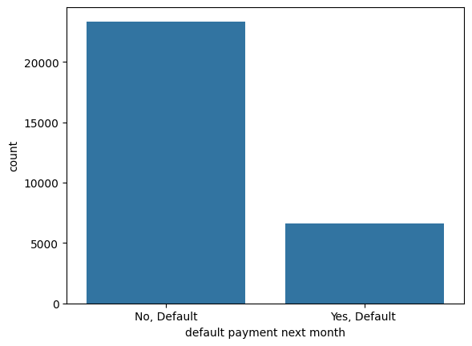

```python
sns.countplot(x='default payment next month', data=Credit_df)
plt.xticks(ticks=[0, 1], labels=["No, Default","Yes, Default "])
plt.show()
```

Visually, we can see the dataset is not balanced. If the data was balanced, the categories of feature `default payment next month` would be evenly divided with about 50% in each category (1 and 0). There are significantly more 0 (no default) compared to 1 (default). We should keep this in mind as we move forward.

Next, we want to see if there are any features that seem to be predicting our target value (default payment next month). So, we used `sns.countplot(x="REPLACE WITH FEATURE NAME", data=Credit_df, hue = 'default payment next month')` to see if we have any of those relationships.

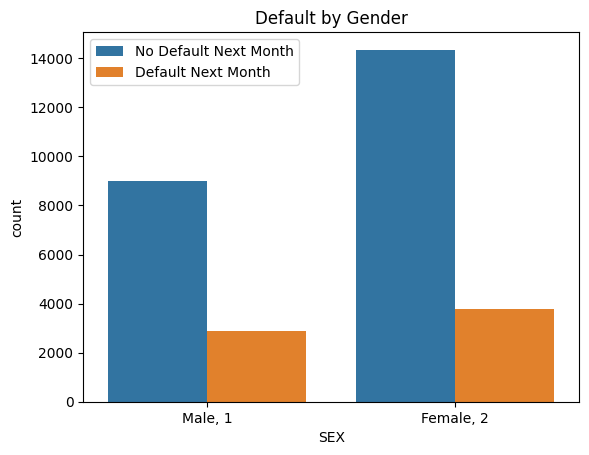

```python
sns.countplot(x="SEX", data=Credit_df, hue = 'default payment next month')
plt.legend(labels = ['No Default Next Month', 'Default Next Month'])
plt.title("Default by Gender")
plt.xticks(ticks=[0, 1], labels=["Male, 1","Female, 2"])
plt.show()
```

The majority of the participants both male and female were unlikely to default with women displaying a even lower chance of defaulting.

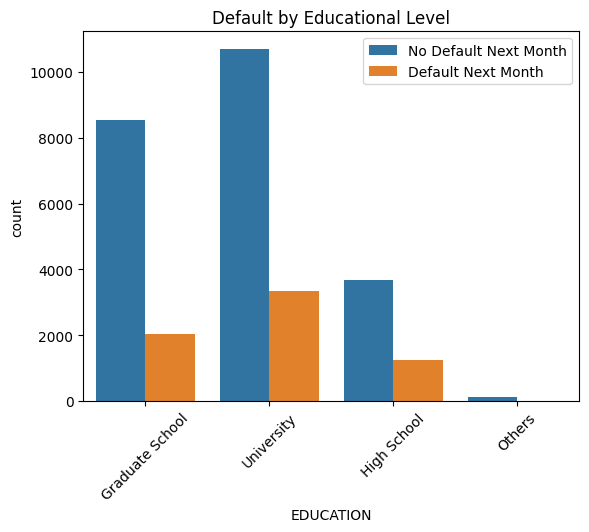

```python
sns.countplot(x="EDUCATION", data=Credit_df, hue = 'default payment next month')
plt.legend(labels = ['No Default Next Month', 'Default Next Month'])
plt.title("Default by Educational Level")
plt.xticks(ticks=[0, 1, 2, 3], labels=['Graduate School', 'University', 'High School', 'Others'], rotation = 45)
plt.show()
```

The imbalanced data is reflected in eduation as well. Most of the participants are not likely to default on payments.

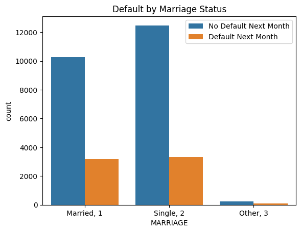

```python
Credit_df = Credit_df[Credit_df['MARRIAGE'].isin([1,2,3])]
sns.countplot(x="MARRIAGE", data=Credit_df, hue = 'default payment next month')
plt.legend(labels = ['No Default Next Month', 'Default Next Month'])
plt.title("Default by Marriage Status")
plt.xticks(ticks=[0, 1,2], labels=["Married, 1","Single, 2","Other, 3"])
plt.show()
```

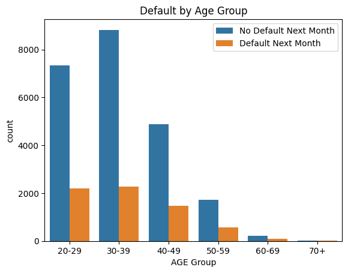

```python
sns.countplot(x="AGE Group", data=Credit_df, hue = 'default payment next month')
plt.legend(labels = ['No Default Next Month', 'Default Next Month'])
plt.title("Default by Age Group")
plt.show()
```

By creating bins for the age, we can see easily individuals are less likely to default.

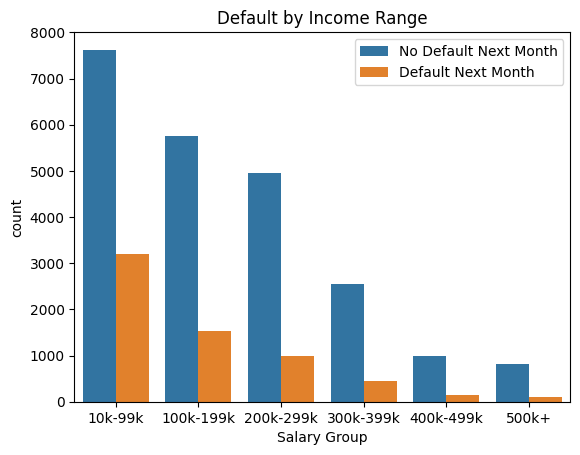

```python
sns.countplot(x="Salary Group", data=Credit_df, hue = 'default payment next month')
plt.legend(labels = ['No Default Next Month', 'Default Next Month'])
plt.title("Default by Income Range")
plt.show()
```

Overall, the imbalance in the data is distributed within the features of the dataset. Whether salary, age, education level, gender (sex) or marital status, there is no relationship that predetermines if a individual will default.

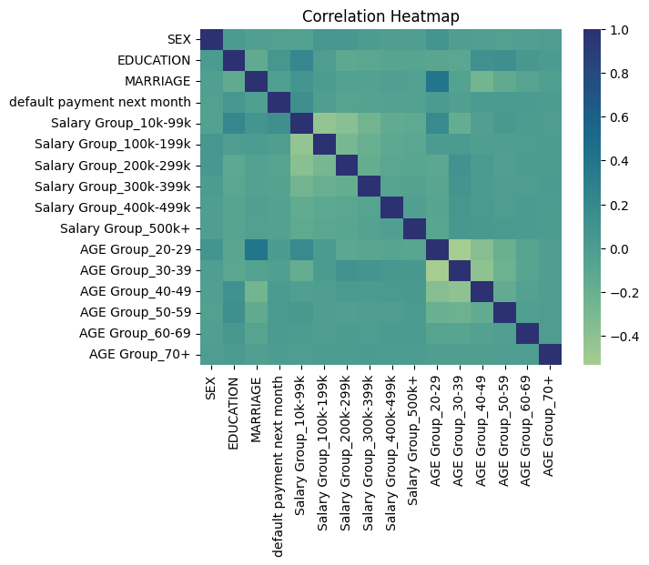

```python
#Credit_df.corr()
Credit_Corr = Credit_df.drop(columns=["ID", "AGE","LIMIT_BAL", "PAY_0",	"PAY_2",	"PAY_3",	"PAY_4",	"PAY_5",
                                      "PAY_6",	"BILL_AMT1",	"BILL_AMT2",	"BILL_AMT3",	"BILL_AMT4",	"BILL_AMT5",
                                      "BILL_AMT6",	"PAY_AMT1",	"PAY_AMT2",	"PAY_AMT3",	"PAY_AMT4",	"PAY_AMT5",	"PAY_AMT6"])
corr = Credit_Corr.corr()
sns.heatmap(data = corr, annot=False, cmap="crest")
plt.title('Correlation Heatmap')
plt.show()
```

Based on the features used, we do not see any correlation with `default payment next month`. Dark blue areass(1.0) would indicate a strong positive correlation. This relationship means as one feature (such as `AGE`) increased, there would be an similar increase in `default payment next month`. Areas in the yellowish-greens (-1.0)indicates a negative relationship. This relationship means as one feature (such as `AGE`) increased, there would be an opposite effect or decrease in `default payment next month`.

### **Modeling**

#### Prep for Training by setting features and target

The following models were selected: decision trees, random forest, downsampling with random forest, naive bayes, and logistic regression. Since our dataset is unbalanced, we can not use k-NN (K Nearest Neighbors).

```python
X = Credit_df.drop(columns =['AGE', 'LIMIT_BAL','default payment next month'])
y = Credit_df['default payment next month']

X.shape, y.shape
```

```
((29601, 34), (29601,))
```

#### Split into Training and Test

Used sklearn librbary to split the data into training and testing data sets. The data was split on 20% which randomly selects 80% for the training data set and 20% for the testing data set.

```python
X_train.shape, X_test.shape, y_train.shape, y_test.shape
```

```
((23680, 34), (5921, 34), (23680,), (5921,))
```

#### **Model 1: Decison Trees**

Decision Trees is a simple boolean decision rules to split each feature in the data and predict the outcome. These trees tend to work well with unbalanced datasets. This spliting (partitioning) is continued until the optiminal criteria is met. Decision tree can be used for classification and regression problems.

This model was chosen because it was the first classification model I learned. I expected and it performed poorly.

pros:

- Easy to interpet and understand
- Handles missing values
- Handles non-linear
- Handles categorical values

cons:

- prone to overfitting
- does not handle changes in data well
- does not handle unbalanced class

#### **Model 2: Random Trees**

Random forest is a good model because of its ability to reduce the risk of overfitting.

The Random Forest is a supervised learning algorithm. It creates decision trees during the training step of the model. Each new tree is created by randomly selecting observations and features from the dataset. This random selection will introduce variability, improve prediction and reduce the risk of overfitting.

In classification, each tree "votes" based on the class (1 or 0 for this project). The forest composed of all of the tree's "votes" and majority wins. The idea is even if a few trees grow to produce errors, the entire forest will make a better decision. The classification algorithm is available in regression and classification.

pro:

- High accuracy
- Handles missing values and outlier
- Less prone to overfitting
- Works well with noise, outliers
- Works well with unbalanced data
- Handles numerical and categorical data

cons:

- Can be difficult to interpret
- Can be prone to overfitting
- Computational complex and can take longer to make predictions

#### **Model 3: Downsampling with Random Forest**

We noted above that our data is unbalanced. About 78% of our observation did not default on the next month's payment, while 22% did default. Another way to address unbalanced data is to either undersample or oversample our dataset. In undersampling, we need to remove observations for the majority class until it equals the minority class. In oversample, we will create random duplicates of the minority class to equal the majority class.

Since it would be necessary to create over 10,000 observations (duplicate), run the risk of overfitting, and could possibly change the composition of the data, we undersampled to see if we get better results.

To ensure that we are pulling from the same training and testing set, we combined the training and testing datasets, created two series separating the majority and minority classes and sampled from the majority class until the count equals the minority. Both classes should have 6,636 observations, however, both ended up having 5,279 observations. Honestly, I am not sure why that was the case but I will be looking into it further.

#### Model 4: Naive Bayes

Naive Bayes uses a probabilistic machine learning algorithm. It is "naive" because it assumes that all features are independent of each other. It based on conditional probability and based on the works of Rev. Thomas Bayes. BernoulliNB classifier is suitable for discrete data and is designed for binary/boolean features.

pros:

- Good performance with high dimensional data
- Not sensitive to irrelevant features
- Scalable

cons:

- Conditional independence assumption does not always stay true.
- Zero probability problem

#### **Modeling 5: Logistic Regression**

Logistic regression is regression model (not a classifier) that predicts the value of a target variable through a linear combination of features. The value is bounded between 0 and 1. It is the probability of success divided by the probability of failures known as log odds. For a binary classification, a probability less than .5 will predict 0. A probability greater than .5 will predict 1.

pros:

- Feature scaling not needed
- Hyperparameters tuning not needed

cons:

- poor performance on non-linear data
- poor performance on with irrelevant features

## Model Evaluation

For this project, we used Decision trees, Random Forest, and Random Forest with downsizing, and Naive Bayes using Bernoulli, and logistic regression.

Since the data was unbalanced, we need to look at other metrics - precision, recall, or F1 score.

Precision is the number of correctly labeled features divided by the total number of features.

Recall is the number of correctly labeled featured divided by the number of features that should have been created.

F1 score is the weighted average of precision and recall. "Accuracy in making positive predictions is measured by a recall, while identifying all positive occurrences in the data is quantified by precision. The F-score ranges from 0 to 1, with higher values indicating better performance."

The downsampling Random Forest scored the best. It was able to predict almost 69% which is better than a random guess, but it has room for improvement. Then working with the entire dataset, the results were similar with Naive Bayes performing at 49.0%. Again, this is worst then guessing.

##### Decision Trees

```python
print(confusion_matrix(y_test, predicted))
print(classification_report(y_test, predicted))
```

```
[[3751  830]
 [ 793  547]]
              precision    recall  f1-score   support

           0       0.83      0.82      0.82      4581
           1       0.40      0.41      0.40      1340

    accuracy                           0.73      5921
   macro avg       0.61      0.61      0.61      5921
weighted avg       0.73      0.73      0.73      5921
```

##### Random Forest

```python
# Random forest
from sklearn.metrics import precision_recall_fscore_support

precision, recall, f1_score, _ = precision_recall_fscore_support(y_test, y_pred2, average='binary')

print("Results for Random Forest")
print(f'Accuracy: {accuracy}')
print(f'Precision: {precision}')
print(f'Recall: {recall}')
print(f'F1 Score: {f1_score}')
```

```
Results for Random Forest
Accuracy: 0.8127005573382875
Precision: 0.6606397774687065
Recall: 0.35447761194029853
F1 Score: 0.46138902379796015
```

##### Downsized Random Forest

```python
# Random forest with downsizing of majority
from sklearn.metrics import precision_recall_fscore_support

precision, recall, f1_score, _ = precision_recall_fscore_support(y_test1, y_pred3, average='binary')

print("Results for Random Forest with downsizing majority")
print(f'Accuracy: {accuracy1}')
print(f'Precision: {precision}')
print(f'Recall: {recall}')
print(f'F1 Score: {f1_score}')
```

```
Results for Random Forest with downsizing majority
Accuracy: 0.7051282051282052
Precision: 0.7283549783549783
Recall: 0.6452540747842761
F1 Score: 0.6842907981698018
```

##### Naive Bayes

```python
print(confusion_matrix(y_test, y_pred5))
print(classification_report(y_test, y_pred5))
```

```
[[3982  599]
 [ 711  629]]
              precision    recall  f1-score   support

           0       0.85      0.87      0.86      4581
           1       0.51      0.47      0.49      1340

    accuracy                           0.78      5921
   macro avg       0.68      0.67      0.67      5921
weighted avg       0.77      0.78      0.78      5921
```

##### Logistic Regression

```python
print(confusion_matrix(y_test, y_pred6))
print(classification_report(y_test, y_pred6))
```

```
[[4452  129]
 [1005  335]]
              precision    recall  f1-score   support

           0       0.82      0.97      0.89      4581
           1       0.72      0.25      0.37      1340

    accuracy                           0.81      5921
   macro avg       0.77      0.61      0.63      5921
weighted avg       0.79      0.81      0.77      5921
```

### Conclusion

The desired impact from this project was to successfully create a model that would predict if an individual would default on the next month's payment or not. Based on the analysis, using downsizing on random forest performed the best.

A business’s ability to predict creditworthiness can save them time and money. On the other side, these models could cause a problem for the individual consumer. The algorithm is using a small window of time to decide if a person is creditworthy. It does not take into consideration other details that could impact one's ability to pay. For example, a person has years of great repayment, and he/she becomes sick, missed payments for two months, but now their repayment schedule is back to normal. The algorithm would likely consider them a risk. Many models are based on history and it's possible that situations could change.

Based on the results, these models were not the best for this project. I plan to revisit this project and use more complex models until I can create an adequate model. In addition, I plan to learn better techniques to help me with these types of datasets. I tried to use SVM which ran for over an hour without producing a result, so I stopped it.

Honestly, 30,000 observations don’t come close to 'big data'.

### References

- [History of Credit](https://www.rocketmoney.com/learn/debt-and-credit/the-history-of-credit)
- [Data Camp - Random Forest](https://www.datacamp.com/tutorial/random-forests-classifier-python)
- [Handling Imbalanced Data](https://towardsdatascience.com/how-to-deal-with-imbalanced-data-34ab7db9b100)
- [Precision, Recall and F1](https://scikit-learn.org/stable/modules/generated/sklearn.metrics.precision_recall_fscore_support.html)
- [Accuracy is not Enough](https://machinelearningmastery.com/classification-accuracy-is-not-enough-more-performance-measures-you-can-use/#)
- [scikit-learn](https://scikit-learn.org/stable/index.html)
- https://www.deepchecks.com/glossary/f-score/